# CSCI E-106: Final Exam - Fall 2020

Hakan Gogtas

12/5/2020

### Instructions

Open book and open notes exam ( textbooks (print or pdf), lecture slides, notes, practice exam, homework solutions, and TA slides, including all Rmd’s*).

You are allowed to use RStudio Cloud (https://rstudio.cloud.) , Microsoft Word, Power Point and PDF reader, and canvas on your laptop.

Proctorio is required to start this exam. If you are prompted for an access code, you must Configure Proctorio on your machine.

Please read the list of recording and restrictions provided by Proctorio carefully before taking the exam

Please pay attention any timing and technical warnings that popped up your screen

The exam will be available from Monday December 14th at 8 am EST through Tuesday December 15th at 8:00pm EST. Once you start the exam, you have to complete the exam in 3 hours or by Tuesday December 15th at 8:00pm EST, whichever comes first.

In order to receive full credit, please provide full explanations and calculations for each questions

Make sure that you are familiar with the procedures for troubleshooting exam issues Preview the document Make sure you submit both .Rmd and (knitted) pdf or html files.

You need to have a camera on your laptop.

## Question 1

Use the “Final Exam Fall 2020 Question 1.csv” data set. Company executives want to be able to predict market share of their product (Y) based on merchandise price ($X_1$), the gross Nielsen rating points ($X_2$), an index of the amount of advertising exposure that the product received); the presence or absence of a wholesale pricing discount ($X_3$ = 1 if discount present: otherwise $X_3$ = 0); the presence or absence of a package promotion during the period ($X_4$ = 1 if promotion present: otherwise $X_4$ = 0). (10 points, 5 points each)

a- ) Use $X_1$, $X_2$, $X_3$, and $X_4$ to predict Y. Develop a best subset model for predicting Y. Justify your choice of model. Ensure that all variables are significant in your final model, use $\alpha=0.05$.

```r
mkt <- read.csv('Final Exam Fall 2020 Question 1.csv')
colnames(mkt)
```

```
## [1] "Market.Share"   "Price"          "Rating.Points"  "Discount.Price"
## [5] "Promotion"      "Month"          "Year"
```

```r
str(mkt)
```

```
## 'data.frame':    36 obs. of  7 variables:
##  $ Market.Share  : num  3.15 2.52 2.64 2.55 2.69 2.38 3.02 2.52 2.45 2.42 ...
##  $ Price         : num  2.2 2.19 2.29 2.42 2.18 ...
##  $ Rating.Points : int  498 510 422 858 566 536 585 310 211 504 ...
##  $ Discount.Price: int  1 0 1 0 1 0 1 1 0 0 ...
##  $ Promotion     : int  1 0 1 1 0 0 1 0 0 1 ...
##  $ Month         : chr  "Sep" "Oct" "Nov" "Dec" ...
##  $ Year          : int  1999 1999 1999 1999 2000 2000 2000 2000 2000 2000 ...
```

```r
p1 <- mkt[,1:5]
str(p1)
```

```
## 'data.frame':    36 obs. of  5 variables:
##  $ Market.Share  : num  3.15 2.52 2.64 2.55 2.69 2.38 3.02 2.52 2.45 2.42 ...
##  $ Price         : num  2.2 2.19 2.29 2.42 2.18 ...
##  $ Rating.Points : int  498 510 422 858 566 536 585 310 211 504 ...
##  $ Discount.Price: int  1 0 1 0 1 0 1 1 0 0 ...
##  $ Promotion     : int  1 0 1 1 0 0 1 0 0 1 ...
```

```r
summary(p1)
```

```
##   Market.Share       Price       Rating.Points   Discount.Price
##  Min.   :2.230   Min.   :2.124   Min.   : 72.0   Min.   :0.0000
##  1st Qu.:2.473   1st Qu.:2.200   1st Qu.:268.0   1st Qu.:0.0000
##  Median :2.640   Median :2.280   Median :412.0   Median :1.0000
##  Mean   :2.664   Mean   :2.324   Mean   :388.1   Mean   :0.5833
##  3rd Qu.:2.880   3rd Qu.:2.420   3rd Qu.:499.5   3rd Qu.:1.0000
##  Max.   :3.160   Max.   :2.781   Max.   :858.0   Max.   :1.0000
##    Promotion
##  Min.   :0.0000
##  1st Qu.:0.0000
##  Median :1.0000
##  Mean   :0.5556
##  3rd Qu.:1.0000
##  Max.   :1.0000
```

```r
tail(p1)
```

|  | Market.Share | Price | Rating.Points | Discount.Price | Promotion |
| --- | --- | --- | --- | --- | --- |
| 31 | 2.99 | 2.233 | 262 | 1 | 0 |
| 32 | 2.30 | 2.302 | 182 | 0 | 1 |
| 33 | 2.88 | 2.421 | 145 | 1 | 1 |
| 34 | 2.80 | 2.518 | 270 | 1 | 0 |
| 35 | 2.48 | 2.497 | 322 | 0 | 1 |
| 36 | 2.85 | 2.781 | 317 | 1 | 1 |

```r
# rename columns
colnames(p1) <- c('Y', 'X1', 'X2', 'X3', 'X4')

# fit simple linear regression
p1_lm <- lm(Y~., data = p1)
summary(p1_lm)
```

```
##
## Call:
## lm(formula = Y ~ ., data = p1)
##
## Residuals:
##       Min        1Q    Median        3Q       Max
## -0.284946 -0.102265 -0.001004  0.103386  0.240284
##
## Coefficients:
##               Estimate Std. Error t value Pr(>|t|)
## (Intercept)  3.158e+00  4.405e-01   7.168 4.67e-08 ***
## X1          -3.439e-01  1.767e-01  -1.946   0.0607 .
## X2           1.993e-05  1.714e-04   0.116   0.9081
## X3           3.999e-01  5.246e-02   7.623 1.35e-08 ***
## X4           1.165e-01  5.394e-02   2.160   0.0386 *
## ---
## Signif. codes:  0 '***' 0.001 '**' 0.01 '*' 0.05 '.' 0.1 ' ' 1
##
## Residual standard error: 0.1522 on 31 degrees of freedom
## Multiple R-squared:  0.7066, Adjusted R-squared:  0.6688
## F-statistic: 18.67 on 4 and 31 DF,  p-value: 6.641e-08
```

```r
# perform best subset selection
p1_best <- ols_step_best_subset(p1_lm, details = TRUE)

# check for max value using AdjR, Cp, AIC
rbind(which.max(p1_best$adjr), which.min(p1_best$aic), which.min(p1_best$cp))
```

```
##      [,1]
## [1,]    3
## [2,]    3
## [3,]    3
```

```r
min_aic <- which.min(p1_best$aic)
```

This shows that model 3 is the best. We proceed to build the regression using model 3

```r
aic_df_cols <- unlist(strsplit(p1_best$predictors[min_aic], split = ' '))
aic_df_cols
```

```
## [1] "X1" "X3" "X4"
```

```r
p1_aic_df <- p1[aic_df_cols]

# add response variable and verify structure
Y <-p1$Y
p1_aic_df <- cbind(Y, p1_aic_df)
str(p1_aic_df)
```

```
## 'data.frame':    36 obs. of  4 variables:
##  $ Y : num  3.15 2.52 2.64 2.55 2.69 2.38 3.02 2.52 2.45 2.42 ...
##  $ X1: num  2.2 2.19 2.29 2.42 2.18 ...
##  $ X3: int  1 0 1 0 1 0 1 1 0 0 ...
##  $ X4: int  1 0 1 1 0 0 1 0 0 1 ...
```

```r
# run regression with shortlisted columns
reg_p1_aic <- lm(Y~., data = p1_aic_df)
summary(reg_p1_aic)
```

```
##
## Call:
## lm(formula = Y ~ ., data = p1_aic_df)
##
## Residuals:
##       Min        1Q    Median        3Q       Max
## -0.286376 -0.100465 -0.002259  0.104174  0.240020
##
## Coefficients:
##             Estimate Std. Error t value Pr(>|t|)
## (Intercept)  3.18527    0.36505   8.726  5.7e-10 ***
## X1          -0.35269    0.15738  -2.241   0.0321 *
## X3           0.39914    0.05125   7.787  7.0e-09 ***
## X4           0.11803    0.05149   2.292   0.0286 *
## ---
## Signif. codes:  0 '***' 0.001 '**' 0.01 '*' 0.05 '.' 0.1 ' ' 1
##
## Residual standard error: 0.1498 on 32 degrees of freedom
## Multiple R-squared:  0.7065, Adjusted R-squared:  0.679
## F-statistic: 25.68 on 3 and 32 DF,  p-value: 1.191e-08
```

b-) Check all the model assumptions (using the residual plots). And test auto correlation, use $\alpha=0.01$. If auto correlation is present, revise the model to eliminate the correlation.

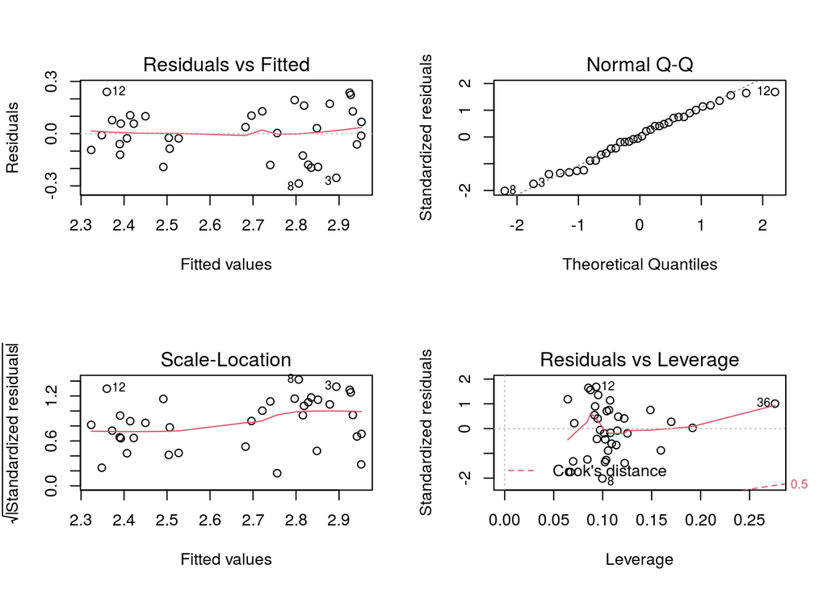

```r
# standard diagnostic plots

newer.par = par(mfrow = c(2,2))
plot(reg_p1_aic)
```

```r
newer.par
```

```
## $mfrow
## [1] 1 1
```

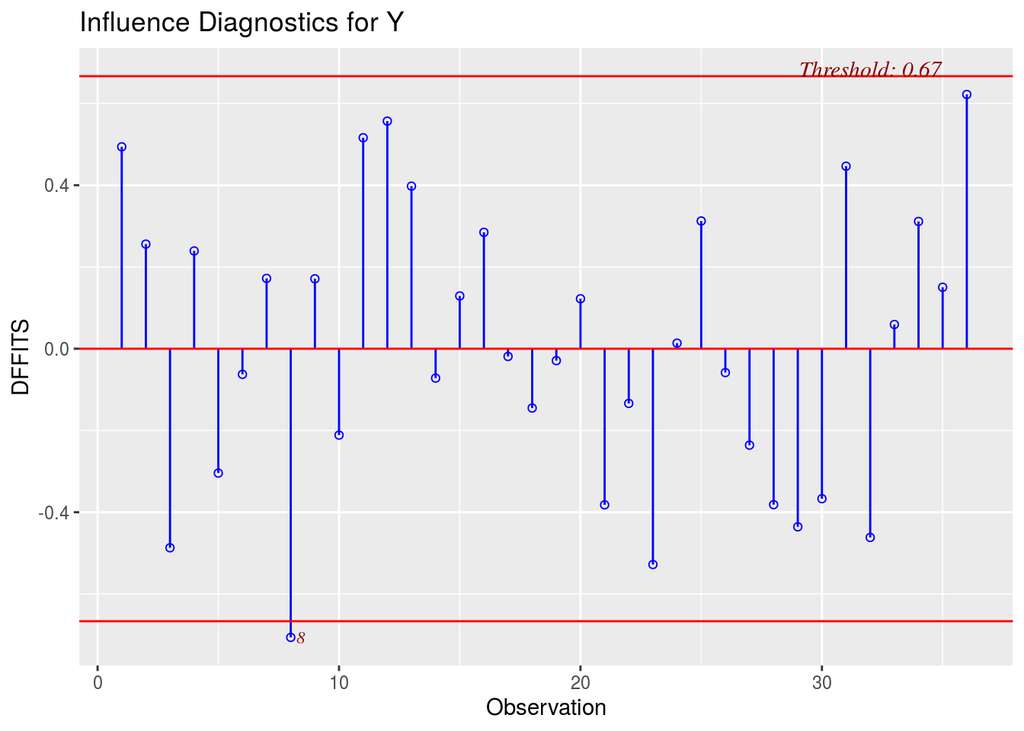

```r
# Measures of influence

# DFFITS Plot - Difference in Fits

ols_plot_dffits(reg_p1_aic)
```

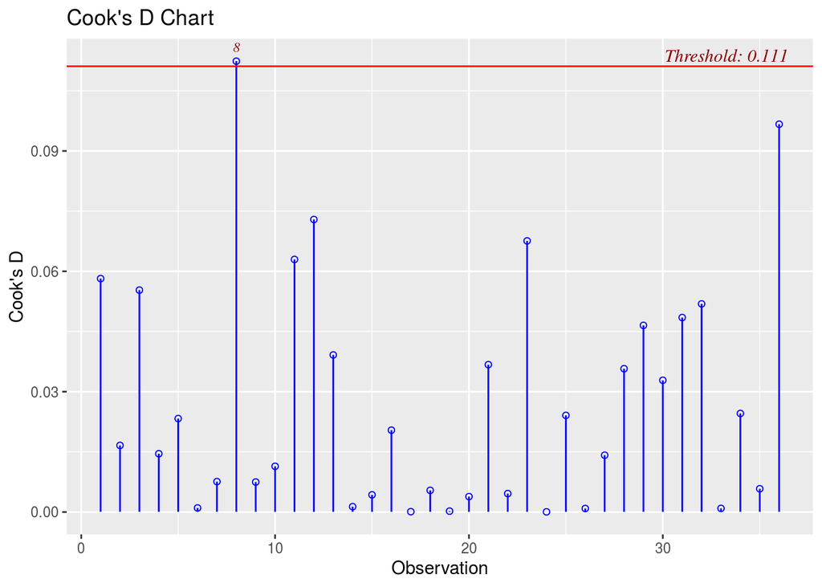

```r
# Cooks Distance Chart
ols_plot_cooksd_chart(reg_p1_aic)
```

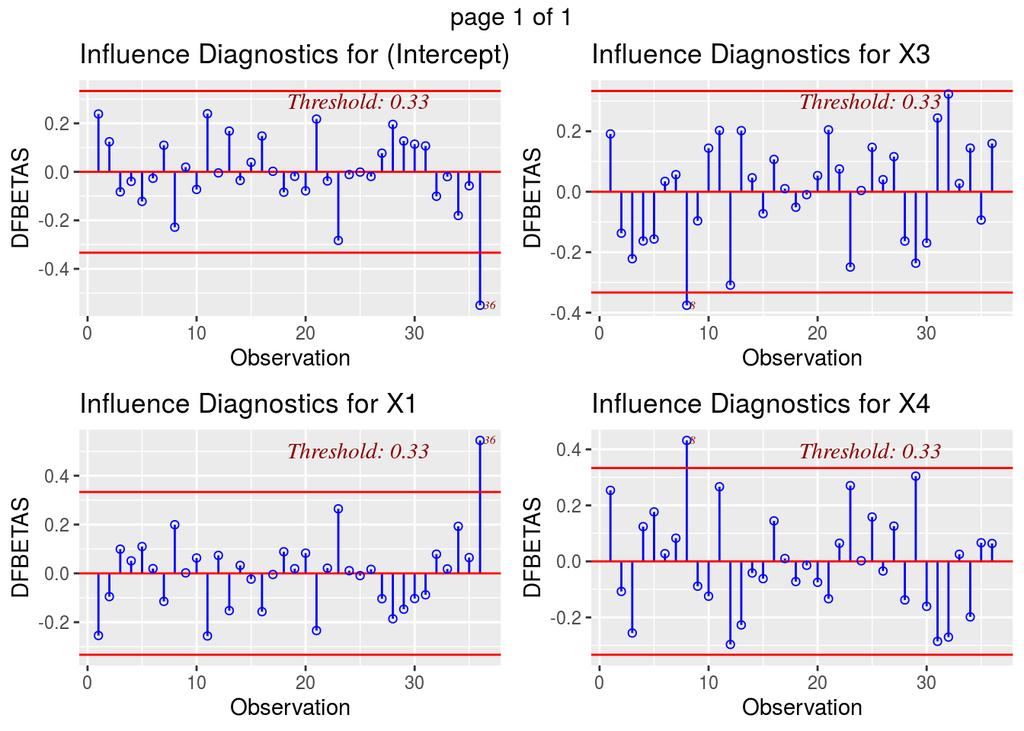

```r
# DFBETAs Panel
ols_plot_dfbetas(reg_p1_aic)
```

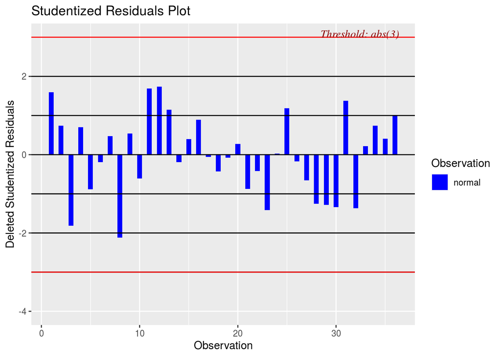

```r
# Studentized residual plot
ols_plot_resid_stud(reg_p1_aic)
```

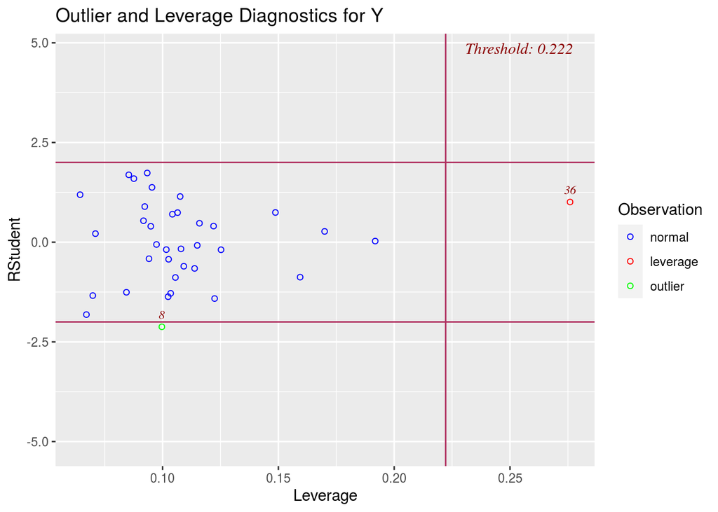

```r
# studentized residuals vs leverage plot
ols_plot_resid_lev(reg_p1_aic)
```

```r
# Outlier Test
outlierTest(reg_p1_aic, cutoff = 0.10, n.max = Inf)
```

```
## No Studentized residuals with Bonferroni p < 0.1
## Largest |rstudent|:
##    rstudent unadjusted p-value Bonferroni p
## 8 -2.122425           0.041894           NA
```

```r
# Durbin Watson test for autocorrelation
dwtest(reg_p1_aic)
```

```
##
##  Durbin-Watson test
##
## data:  reg_p1_aic
## DW = 1.8511, p-value = 0.3484
## alternative hypothesis: true autocorrelation is greater than 0
```

DW Test Ho : No autocorrelation; Ha: There is autocorrelation; alpha = 0.01 As seen above, p-value of 0.3484 indicates that there is no autocorrelation.

## Question 2

Use the “Final Exam Fall 2020 Question 2.csv” data set. Residential sales that occurred during the year 2002 were available from a city in the midwest. Data on 522 arms-length transactions include following variables:

sales price,

finished square feet,

number of bedrooms,

number of bathrooms,

air conditioning (1 if yes; 0 otherwise)

garage size

pool (1 if yes; 0 otherwise),

year built,

quality (3 different qualities),

style (there are 7 different styles, 1 to 7),

lot size,

year built.

(50 points)

a-) Use “set.seed(300)” to create development sample (70% of the data) and hold-out sample (30% of the data). (5 points)

```r
p2 <- read.csv('Final Exam Fall 2020 Question 2.csv')
colnames(p2)
```

```
##  [1] "Sales.price"          "Finished.square.feet" "Number.of.bedrooms"
##  [4] "Number.of.bathrooms"  "Air.conditioning"     "Garage.size"
##  [7] "Pool"                 "Year.built"           "Quality"
## [10] "Style"                "Lot.size"             "Adjacent.to.highway"
```

```r
str(p2)
```

```
## 'data.frame':    522 obs. of  12 variables:
##  $ Sales.price         : int  360000 340000 250000 205500 275500 248000 229900 150000 195000 160000 ...
##  $ Finished.square.feet: int  3032 2058 1780 1638 2196 1966 2216 1597 1622 1976 ...
##  $ Number.of.bedrooms  : int  4 4 4 4 4 4 3 2 3 3 ...
##  $ Number.of.bathrooms : int  4 2 3 2 3 3 2 1 2 3 ...
##  $ Air.conditioning    : int  1 1 1 1 1 1 1 1 1 0 ...
##  $ Garage.size         : int  2 2 2 2 2 5 2 1 2 1 ...
##  $ Pool                : int  0 0 0 0 0 1 0 0 0 0 ...
##  $ Year.built          : int  1972 1976 1980 1963 1968 1972 1972 1955 1975 1918 ...
##  $ Quality             : int  2 2 2 2 2 2 2 2 3 3 ...
##  $ Style               : int  1 1 1 1 7 1 7 1 1 1 ...
##  $ Lot.size            : int  22221 22912 21345 17342 21786 18902 18639 22112 14321 32358 ...
##  $ Adjacent.to.highway : int  0 0 0 0 0 0 0 0 0 0 ...
```

```r
summary(p2)
```

```
##   Sales.price     Finished.square.feet Number.of.bedrooms Number.of.bathrooms
##  Min.   : 84000   Min.   : 980         Min.   :0.000      Min.   :0.000
##  1st Qu.:180000   1st Qu.:1701         1st Qu.:3.000      1st Qu.:2.000
##  Median :229900   Median :2061         Median :3.000      Median :3.000
##  Mean   :277894   Mean   :2261         Mean   :3.471      Mean   :2.642
##  3rd Qu.:335000   3rd Qu.:2636         3rd Qu.:4.000      3rd Qu.:3.000
##  Max.   :920000   Max.   :5032         Max.   :7.000      Max.   :7.000
##  Air.conditioning  Garage.size       Pool           Year.built
##  Min.   :0.0000   Min.   :0.0   Min.   :0.00000   Min.   :1885
##  1st Qu.:1.0000   1st Qu.:2.0   1st Qu.:0.00000   1st Qu.:1956
##  Median :1.0000   Median :2.0   Median :0.00000   Median :1966
##  Mean   :0.8314   Mean   :2.1   Mean   :0.06897   Mean   :1967
##  3rd Qu.:1.0000   3rd Qu.:2.0   3rd Qu.:0.00000   3rd Qu.:1981
##  Max.   :1.0000   Max.   :7.0   Max.   :1.00000   Max.   :1998
##     Quality          Style          Lot.size     Adjacent.to.highway
##  Min.   :1.000   Min.   :1.000   Min.   : 4560   Min.   :0.00000
##  1st Qu.:2.000   1st Qu.:1.000   1st Qu.:17205   1st Qu.:0.00000
##  Median :2.000   Median :2.000   Median :22200   Median :0.00000
##  Mean   :2.184   Mean   :3.328   Mean   :24370   Mean   :0.02107
##  3rd Qu.:3.000   3rd Qu.:7.000   3rd Qu.:26787   3rd Qu.:0.00000
##  Max.   :3.000   Max.   :7.000   Max.   :86830   Max.   :1.00000
```

```r
tail(p2)
```

|  | Sales.price | Finished.square.feet | Number.of.bedrooms | Number.of.bathrooms | Air.conditioning | Garage.size | Pool | Year.built | Quality | Style | Lot.size | Adjacent.to.highway |
| --- | --- | --- | --- | --- | --- | --- | --- | --- | --- | --- | --- | --- |
| 517 | 136900 | 1409 | 2 | 1 | 0 | 1 | 0 | 1951 | 3 | 1 | 28421 | 0 |
| 518 | 137000 | 1655 | 2 | 1 | 0 | 1 | 0 | 1935 | 3 | 1 | 54651 | 0 |
| 519 | 185000 | 1944 | 3 | 2 | 1 | 2 | 0 | 1939 | 3 | 6 | 17999 | 0 |
| 520 | 133500 | 1922 | 3 | 1 | 0 | 2 | 0 | 1950 | 3 | 1 | 14805 | 0 |
| 521 | 124000 | 1480 | 3 | 2 | 1 | 2 | 0 | 1953 | 3 | 1 | 28351 | 0 |
| 522 | 95500 | 1184 | 2 | 1 | 0 | 1 | 0 | 1951 | 3 | 1 | 14786 | 0 |

```r
# rename columns
p2a <- p2
colnames(p2a) <- c('Y', 'X1', 'X2', 'X3', 'X4', 'X5', 'X6', 'X7', 'X8', 'X9', 'X10', 'X11')
str(p2a)
```

```
## 'data.frame':    522 obs. of  12 variables:
##  $ Y  : int  360000 340000 250000 205500 275500 248000 229900 150000 195000 160000 ...
##  $ X1 : int  3032 2058 1780 1638 2196 1966 2216 1597 1622 1976 ...
##  $ X2 : int  4 4 4 4 4 4 3 2 3 3 ...
##  $ X3 : int  4 2 3 2 3 3 2 1 2 3 ...
##  $ X4 : int  1 1 1 1 1 1 1 1 1 0 ...
##  $ X5 : int  2 2 2 2 2 5 2 1 2 1 ...
##  $ X6 : int  0 0 0 0 0 1 0 0 0 0 ...
##  $ X7 : int  1972 1976 1980 1963 1968 1972 1972 1955 1975 1918 ...
##  $ X8 : int  2 2 2 2 2 2 2 2 3 3 ...
##  $ X9 : int  1 1 1 1 7 1 7 1 1 1 ...
##  $ X10: int  22221 22912 21345 17342 21786 18902 18639 22112 14321 32358 ...
##  $ X11: int  0 0 0 0 0 0 0 0 0 0 ...
```

```r
table(p2a$X4) # 0,1 no dummy needed - AC Yes No
```

```
##
##   0   1
##  88 434
```

```r
table(p2a$X6) # 0,1 no dummy needed - Pool yes no
```

```
##
##   0   1
## 486  36
```

```r
table(p2a$X8) # 1,2,3 - dummy needed - 3 different qualities
```

```
##
##   1   2   3
##  68 290 164
```

```r
table(p2a$X9) # 1-7 - dummy needed - 7 different style types
```

```
##
##   1   2   3   4   5   6   7
## 214  58  64  11  18  18 139
```

```r
table(p2a$X11) # # 0,1 - no dummy needed
```

```
##
##   0   1
## 511  11
```

```r
# create dummy variables for x8 and x9
p2a <- dummy_cols(p2a, select_columns = 'X8')
p2a <- dummy_cols(p2a, select_columns = 'X9')
#check
str(p2a)
```

```
## 'data.frame':    522 obs. of  22 variables:
##  $ Y   : int  360000 340000 250000 205500 275500 248000 229900 150000 195000 160000 ...
##  $ X1  : int  3032 2058 1780 1638 2196 1966 2216 1597 1622 1976 ...
##  $ X2  : int  4 4 4 4 4 4 3 2 3 3 ...
##  $ X3  : int  4 2 3 2 3 3 2 1 2 3 ...
##  $ X4  : int  1 1 1 1 1 1 1 1 1 0 ...
##  $ X5  : int  2 2 2 2 2 5 2 1 2 1 ...
##  $ X6  : int  0 0 0 0 0 1 0 0 0 0 ...
##  $ X7  : int  1972 1976 1980 1963 1968 1972 1972 1955 1975 1918 ...
##  $ X8  : int  2 2 2 2 2 2 2 2 3 3 ...
##  $ X9  : int  1 1 1 1 7 1 7 1 1 1 ...
##  $ X10 : int  22221 22912 21345 17342 21786 18902 18639 22112 14321 32358 ...
##  $ X11 : int  0 0 0 0 0 0 0 0 0 0 ...
##  $ X8_1: int  0 0 0 0 0 0 0 0 0 0 ...
##  $ X8_2: int  1 1 1 1 1 1 1 1 0 0 ...
##  $ X8_3: int  0 0 0 0 0 0 0 0 1 1 ...
##  $ X9_1: int  1 1 1 1 0 1 0 1 1 1 ...
##  $ X9_2: int  0 0 0 0 0 0 0 0 0 0 ...
##  $ X9_3: int  0 0 0 0 0 0 0 0 0 0 ...
##  $ X9_4: int  0 0 0 0 0 0 0 0 0 0 ...
##  $ X9_5: int  0 0 0 0 0 0 0 0 0 0 ...
##  $ X9_6: int  0 0 0 0 0 0 0 0 0 0 ...
##  $ X9_7: int  0 0 0 0 1 0 1 0 0 0 ...
```

```r
# drop redundant columns and check
p2dummy <- p2a[,-c(9,10,13,16)]; colnames(p2dummy)
```

```
##  [1] "Y"    "X1"   "X2"   "X3"   "X4"   "X5"   "X6"   "X7"   "X10"  "X11"
## [11] "X8_2" "X8_3" "X9_2" "X9_3" "X9_4" "X9_5" "X9_6" "X9_7"
```

```r
# split into development and holdout
set.seed(300)
ind <- sample(1:nrow(p2dummy), round(0.7*nrow(p2dummy),0)); length(ind)
```

```
## [1] 365
```

```r
dev2a <- p2dummy[ind,]; dim(dev2a)
```

```
## [1] 365  18
```

```r
ho2a <- p2dummy[-ind,]; dim(ho2a)
```

```
## [1] 157  18
```

b-) Use all variables to predict the sales price on the development sample. Transform the sales price and refit the model. Explain why a transformation would be necessary in this case.(5 points)

```r
lm2b <- lm(Y~., data = dev2a)
summary(lm2b)
```

```
##
## Call:
## lm(formula = Y ~ ., data = dev2a)
##
## Residuals:
##     Min      1Q  Median      3Q     Max
## -184151  -26758   -3019   26804  203300
##
## Coefficients:
##               Estimate Std. Error t value Pr(>|t|)
## (Intercept) -2.717e+06  4.613e+05  -5.891 9.10e-09 ***
## X1           1.005e+02  8.576e+00  11.720  < 2e-16 ***
## X2          -4.622e+03  3.718e+03  -1.243 0.214601
## X3           4.931e+03  4.885e+03   1.009 0.313461
## X4           6.894e+03  9.195e+03   0.750 0.453899
## X5           1.450e+04  5.568e+03   2.605 0.009578 **
## X6           1.616e+04  1.112e+04   1.453 0.147140
## X7           1.437e+03  2.349e+02   6.116 2.58e-09 ***
## X10          1.021e+00  2.713e-01   3.762 0.000198 ***
## X11         -3.046e+04  2.016e+04  -1.511 0.131718
## X8_2        -1.205e+05  1.157e+04 -10.418  < 2e-16 ***
## X8_3        -1.263e+05  1.573e+04  -8.032 1.52e-14 ***
## X9_2        -2.091e+04  1.039e+04  -2.012 0.045040 *
## X9_3        -8.148e+03  1.005e+04  -0.811 0.418042
## X9_4         2.282e+03  2.162e+04   0.106 0.916001
## X9_5        -2.517e+04  1.711e+04  -1.471 0.142253
## X9_6         5.117e+03  1.849e+04   0.277 0.782123
## X9_7        -3.357e+04  9.643e+03  -3.482 0.000562 ***
## ---
## Signif. codes:  0 '***' 0.001 '**' 0.01 '*' 0.05 '.' 0.1 ' ' 1
##
## Residual standard error: 54530 on 347 degrees of freedom
## Multiple R-squared:  0.844,  Adjusted R-squared:  0.8364
## F-statistic: 110.4 on 17 and 347 DF,  p-value: < 2.2e-16
```

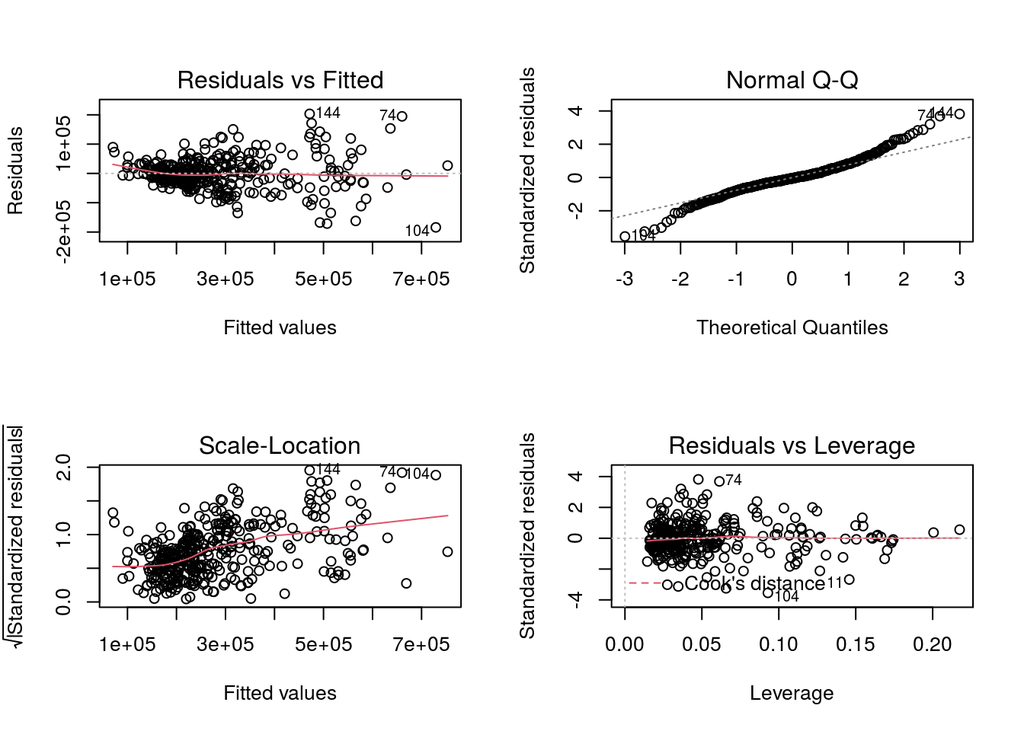

```r
# check diagnostic plots
newer.par = par(mfrow = c(2,2))
plot(lm2b)
```

```r
newer.par
```

```
## $mfrow
## [1] 1 1
```

Funnel shaped distribution of the plot indicates heteroskedasticity. Hence we transform the response variable.

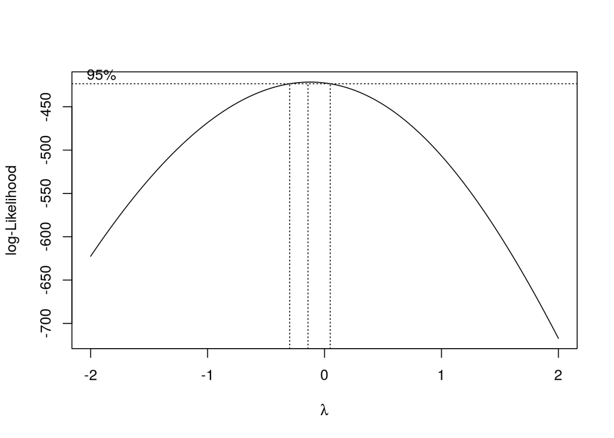

```r
# boxcox to decied transform
boxcox(lm2b, lambda = seq(-2, 2, by = 0.1))
```

BoxCox transform indicates lambda = 0 is best. Hence, we take log of response variable

```r
lm2b_log <- lm(log(Y)~., data = dev2a)
summary(lm2b_log)
```

```
##
## Call:
## lm(formula = log(Y) ~ ., data = dev2a)
##
## Residuals:
##      Min       1Q   Median       3Q      Max
## -0.63820 -0.10721 -0.00662  0.10843  0.42645
##
## Coefficients:
##               Estimate Std. Error t value Pr(>|t|)
## (Intercept)  2.702e+00  1.445e+00   1.870  0.06237 .
## X1           2.773e-04  2.687e-05  10.323  < 2e-16 ***
## X2           5.394e-03  1.165e-02   0.463  0.64350
## X3           3.545e-02  1.530e-02   2.317  0.02111 *
## X4           7.541e-02  2.880e-02   2.618  0.00923 **
## X5           4.379e-02  1.744e-02   2.511  0.01250 *
## X6           6.640e-02  3.485e-02   1.905  0.05755 .
## X7           4.573e-03  7.358e-04   6.215 1.47e-09 ***
## X10          4.103e-06  8.500e-07   4.827 2.08e-06 ***
## X11         -4.511e-02  6.316e-02  -0.714  0.47557
## X8_2        -2.516e-01  3.623e-02  -6.942 1.90e-11 ***
## X8_3        -3.397e-01  4.927e-02  -6.896 2.55e-11 ***
## X9_2        -5.169e-02  3.256e-02  -1.588  0.11327
## X9_3         1.166e-02  3.148e-02   0.370  0.71131
## X9_4         3.317e-02  6.773e-02   0.490  0.62462
## X9_5        -2.735e-02  5.360e-02  -0.510  0.61019
## X9_6         8.053e-02  5.791e-02   1.391  0.16521
## X9_7        -6.905e-02  3.021e-02  -2.286  0.02287 *
## ---
## Signif. codes:  0 '***' 0.001 '**' 0.01 '*' 0.05 '.' 0.1 ' ' 1
##
## Residual standard error: 0.1708 on 347 degrees of freedom
## Multiple R-squared:  0.8475, Adjusted R-squared:   0.84
## F-statistic: 113.4 on 17 and 347 DF,  p-value: < 2.2e-16
```

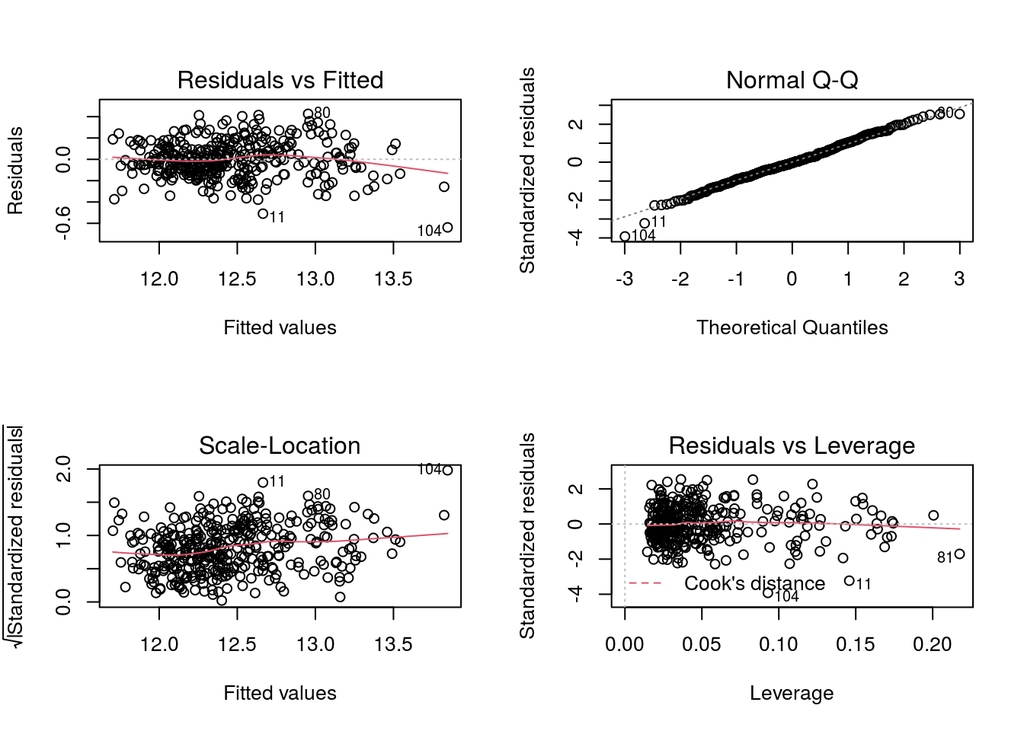

```r
# check diagnostic plots
newer.par = par(mfrow = c(2,2))
plot(lm2b_log)
```

```r
newer.par
```

```
## $mfrow
## [1] 1 1
```

Regression diagnostic plots above show that all residual vs fitted is random and QQ plot is in a straight line.

This indicates that regression assumptions are satisfied.

c-) Use stepwise (both ways) model selection to select the best model for predicting transformed sales price on the development sample.**Ensure that all variables are significant, use $\alpha=0.05$. Justify your choice of model. Check the appropriate model assumptions visually from the graphs.** (5 points)

```r
best2c <- ols_step_both_p(lm2b_log, pent = 0.9, prem = 0.05, details = TRUE)
```

```
## Stepwise Selection Method
## ---------------------------
##
## Candidate Terms:
##
## 1. X1
## 2. X2
## 3. X3
## 4. X4
## 5. X5
## 6. X6
## 7. X7
## 8. X10
## 9. X11
## 10. X8_2
## 11. X8_3
## 12. X9_2
## 13. X9_3
## 14. X9_4
## 15. X9_5
## 16. X9_6
## 17. X9_7
##
## We are selecting variables based on p value...
##
##
## Stepwise Selection: Step 1
##
## - X1 added
##
##                         Model Summary
## -------------------------------------------------------------
## R                       0.843       RMSE               0.230
## R-Squared               0.711       Coef. Var          1.847
## Adj. R-Squared          0.710       MSE                0.053
## Pred R-Squared          0.708       MAE                0.174
## -------------------------------------------------------------
##  RMSE: Root Mean Square Error
##  MSE: Mean Square Error
##  MAE: Mean Absolute Error
```

[output cut: 1662 more lines]

```
##                                   Parameter Estimates
## ----------------------------------------------------------------------------------------
##       model      Beta    Std. Error    Std. Beta      t        Sig      lower     upper
## ----------------------------------------------------------------------------------------
## (Intercept)     3.351         1.369                  2.448    0.015     0.660     6.043
##          X1     0.000         0.000        0.505    12.214    0.000     0.000     0.000
##          X7     0.004         0.001        0.177     6.083    0.000     0.003     0.006
##          X5     0.046         0.017        0.071     2.653    0.008     0.012     0.080
##         X10     0.000         0.000        0.107     4.795    0.000     0.000     0.000
##        X9_7    -0.072         0.026       -0.076    -2.721    0.007    -0.124    -0.020
##          X3     0.038         0.015        0.096     2.617    0.009     0.010     0.067
##          X4     0.080         0.029        0.070     2.797    0.005     0.024     0.136
##        X8_2    -0.241         0.035       -0.281    -6.845    0.000    -0.311    -0.172
##        X8_3    -0.322         0.048       -0.348    -6.645    0.000    -0.417    -0.227
## ----------------------------------------------------------------------------------------
```

```r
best2c$predictors
```

```
## [1] "X1"   "X7"   "X5"   "X10"  "X9_7" "X3"   "X4"   "X8_2" "X8_3"
```

```r
# extract predictors and create df of relevant columns
best2c_df_cols <- unlist(best2c$predictors)
best2c_df_cols
```

```
## [1] "X1"   "X7"   "X5"   "X10"  "X9_7" "X3"   "X4"   "X8_2" "X8_3"
```

```r
best2c_df <- dev2a[best2c_df_cols]; str(best2c_df)
```

```
## 'data.frame':    365 obs. of  9 variables:
##  $ X1  : int  2094 1596 2042 3808 1821 4453 4022 1502 2028 2184 ...
##  $ X7  : int  1984 1940 1963 1982 1956 1974 1986 1956 1951 1977 ...
##  $ X5  : int  2 0 2 3 2 2 3 2 2 2 ...
##  $ X10 : int  18617 28357 21849 23324 16696 15595 18429 28958 26777 19090 ...
##  $ X9_7: int  0 0 0 1 0 1 1 0 0 0 ...
##  $ X3  : int  3 1 3 4 2 5 4 2 2 3 ...
##  $ X4  : int  1 0 0 1 1 1 1 1 1 1 ...
##  $ X8_2: int  1 0 1 0 0 0 1 1 1 1 ...
##  $ X8_3: int  0 1 0 0 1 0 0 0 0 0 ...
```

```r
# add response variable and verify structure
Y <-dev2a$Y
best2c_df <- cbind(Y, best2c_df)
str(best2c_df)
```

```
## 'data.frame':    365 obs. of  10 variables:
##  $ Y   : int  217000 132000 195000 578000 219900 465000 430000 169900 204400 274000 ...
##  $ X1  : int  2094 1596 2042 3808 1821 4453 4022 1502 2028 2184 ...
##  $ X7  : int  1984 1940 1963 1982 1956 1974 1986 1956 1951 1977 ...
##  $ X5  : int  2 0 2 3 2 2 3 2 2 2 ...
##  $ X10 : int  18617 28357 21849 23324 16696 15595 18429 28958 26777 19090 ...
##  $ X9_7: int  0 0 0 1 0 1 1 0 0 0 ...
##  $ X3  : int  3 1 3 4 2 5 4 2 2 3 ...
##  $ X4  : int  1 0 0 1 1 1 1 1 1 1 ...
##  $ X8_2: int  1 0 1 0 0 0 1 1 1 1 ...
##  $ X8_3: int  0 1 0 0 1 0 0 0 0 0 ...
```

```r
# run regression with shortlisted columns
lmbest2c <- lm(Y~., data = best2c_df)
summary(lmbest2c)
```

```
##
## Call:
## lm(formula = Y ~ ., data = best2c_df)
##
## Residuals:
##     Min      1Q  Median      3Q     Max
## -172551  -27786   -3821   22386  206320
##
## Coefficients:
##               Estimate Std. Error t value Pr(>|t|)
## (Intercept) -2.562e+06  4.387e+05  -5.841 1.17e-08 ***
## X1           9.861e+01  7.782e+00  12.672  < 2e-16 ***
## X7           1.351e+03  2.223e+02   6.076 3.17e-09 ***
## X5           1.582e+04  5.572e+03   2.839 0.004779 **
## X10          9.619e-01  2.668e-01   3.605 0.000356 ***
## X9_7        -2.597e+04  8.456e+03  -3.072 0.002293 **
## X3           3.737e+03  4.708e+03   0.794 0.427789
## X4           8.169e+03  9.139e+03   0.894 0.372011
## X8_2        -1.238e+05  1.129e+04 -10.960  < 2e-16 ***
## X8_3        -1.270e+05  1.554e+04  -8.177 5.23e-15 ***
## ---
## Signif. codes:  0 '***' 0.001 '**' 0.01 '*' 0.05 '.' 0.1 ' ' 1
##
## Residual standard error: 54860 on 355 degrees of freedom
## Multiple R-squared:  0.8385, Adjusted R-squared:  0.8344
## F-statistic: 204.7 on 9 and 355 DF,  p-value: < 2.2e-16
```

summary shows that X3 and X4 are not significant. We drop them

```r
best2c_df_final <- best2c_df[,-c(7,8)]; str(best2c_df_final)
```

```
## 'data.frame':    365 obs. of  8 variables:
##  $ Y   : int  217000 132000 195000 578000 219900 465000 430000 169900 204400 274000 ...
##  $ X1  : int  2094 1596 2042 3808 1821 4453 4022 1502 2028 2184 ...
##  $ X7  : int  1984 1940 1963 1982 1956 1974 1986 1956 1951 1977 ...
##  $ X5  : int  2 0 2 3 2 2 3 2 2 2 ...
##  $ X10 : int  18617 28357 21849 23324 16696 15595 18429 28958 26777 19090 ...
##  $ X9_7: int  0 0 0 1 0 1 1 0 0 0 ...
##  $ X8_2: int  1 0 1 0 0 0 1 1 1 1 ...
##  $ X8_3: int  0 1 0 0 1 0 0 0 0 0 ...
```

```r
lm_best2c_final <- lm(Y~., data = best2c_df_final)
summary(lm_best2c_final)
```

```
##
## Call:
## lm(formula = Y ~ ., data = best2c_df_final)
##
## Residuals:
##     Min      1Q  Median      3Q     Max
## -175800  -27619   -2834   21587  203770
##
## Coefficients:
##               Estimate Std. Error t value Pr(>|t|)
## (Intercept) -2.689e+06  4.261e+05  -6.311 8.20e-10 ***
## X1           1.018e+02  6.912e+00  14.731  < 2e-16 ***
## X7           1.420e+03  2.148e+02   6.608 1.42e-10 ***
## X5           1.653e+04  5.538e+03   2.985 0.003030 **
## X10          9.426e-01  2.612e-01   3.609 0.000351 ***
## X9_7        -2.577e+04  8.373e+03  -3.078 0.002248 **
## X8_2        -1.233e+05  1.126e+04 -10.945  < 2e-16 ***
## X8_3        -1.303e+05  1.527e+04  -8.531 4.20e-16 ***
## ---
## Signif. codes:  0 '***' 0.001 '**' 0.01 '*' 0.05 '.' 0.1 ' ' 1
##
## Residual standard error: 54830 on 357 degrees of freedom
## Multiple R-squared:  0.8378, Adjusted R-squared:  0.8346
## F-statistic: 263.3 on 7 and 357 DF,  p-value: < 2.2e-16
```

d-) Use regression Tree to predict the sales price on the development sample (use 3 digits). (5 points)

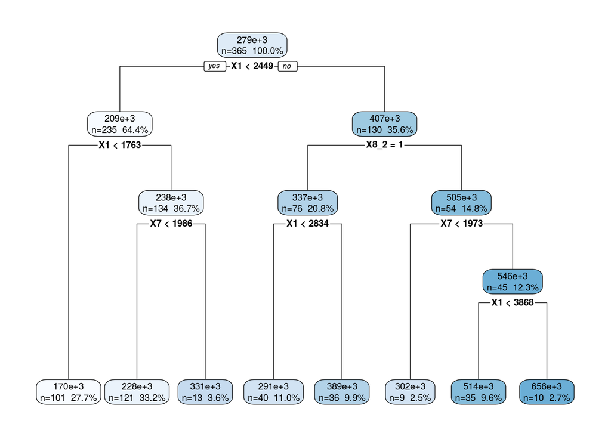

```r
tree2d <- rpart(Y~., data = dev2a)
plot_tree2d <- rpart.plot(tree2d, digits = 3, fallen.leaves = TRUE, type = 2, extra = 101)
```

```r
dev2a_tree_pred <- predict(tree2d, dev2a)
```

e-) Use Neural Network approach to predict the sales price on the development sample. (10 points)

```r
normalize <- function(x) {
  return((x-min(x))/(max(x) - min(x)))
}

dev2a_norm <- as.data.frame(lapply(dev2a, normalize))
head(dev2a_norm)
```

|  | Y | X1 | X2 | X3 | X4 | X5 | X6 | X7 | X10 | X11 | X8_2 | X8_3 | X9_2 | X9_3 | X9_4 | X9_5 | X9_6 | X9_7 |
| --- | --- | --- | --- | --- | --- | --- | --- | --- | --- | --- | --- | --- | --- | --- | --- | --- | --- | --- |
| 1 | 0.17250324 | 0.2789882 | 0.5000000 | 0.3333333 | 1 | 0.2857143 | 0 | 0.8839286 | 0.1714038 | 0 | 1 | 0 | 0 | 1 | 0 | 0 | 0 | 0 |
| 2 | 0.06225681 | 0.1542700 | 0.0000000 | 0.0000000 | 0 | 0.0000000 | 0 | 0.4910714 | 0.2901684 | 0 | 0 | 1 | 0 | 0 | 0 | 0 | 0 | 0 |
| 3 | 0.14396887 | 0.2659654 | 0.5000000 | 0.3333333 | 0 | 0.2857143 | 0 | 0.6964286 | 0.2108132 | 0 | 1 | 0 | 1 | 0 | 0 | 0 | 0 | 0 |
| 4 | 0.64072633 | 0.7082394 | 0.6666667 | 0.5000000 | 1 | 0.4285714 | 0 | 0.8660714 | 0.2287986 | 0 | 0 | 0 | 0 | 0 | 0 | 0 | 0 | 1 |
| 5 | 0.17626459 | 0.2106186 | 0.5000000 | 0.1666667 | 1 | 0.2857143 | 0 | 0.6339286 | 0.1479801 | 0 | 0 | 1 | 0 | 0 | 0 | 0 | 0 | 0 |
| 6 | 0.49416342 | 0.8697721 | 1.0000000 | 0.6666667 | 1 | 0.2857143 | 0 | 0.7946429 | 0.1345551 | 0 | 0 | 0 | 0 | 0 | 0 | 0 | 0 | 1 |

```r
ho2a_norm <- as.data.frame(lapply(ho2a, normalize))
head(ho2a_norm)
```

|  | Y | X1 | X2 | X3 | X4 | X5 | X6 | X7 | X10 | X11 | X8_2 | X8_3 | X9_2 | X9_3 | X9_4 | X9_5 | X9_6 | X9_7 |
| --- | --- | --- | --- | --- | --- | --- | --- | --- | --- | --- | --- | --- | --- | --- | --- | --- | --- | --- |
| 1 | 0.31372549 | 0.4693553 | 0.5714286 | 0.8 | 1 | 0.6666667 | 0 | 0.6904762 | 0.2039697 | 0 | 1 | 0 | 0 | 0 | 0 | 0 | 0 | 0 |
| 2 | 0.51838235 | 0.5224197 | 0.7142857 | 1.0 | 1 | 0.6666667 | 0 | 0.8333333 | 0.1944089 | 0 | 1 | 0 | 0 | 0 | 0 | 0 | 1 | 0 |
| 3 | 0.13235294 | 0.1326612 | 0.4285714 | 0.6 | 1 | 0.6666667 | 0 | 0.5357143 | 0.2348332 | 0 | 1 | 0 | 0 | 0 | 0 | 0 | 0 | 0 |
| 4 | 0.17279412 | 0.3327142 | 0.5714286 | 0.6 | 1 | 0.6666667 | 0 | 0.6071429 | 0.2167833 | 0 | 1 | 0 | 0 | 0 | 0 | 0 | 0 | 0 |
| 5 | 0.04460784 | 0.1615813 | 0.4285714 | 0.4 | 1 | 0.6666667 | 0 | 0.8452381 | 0.2260978 | 0 | 1 | 0 | 0 | 1 | 0 | 0 | 0 | 0 |
| 6 | 0.15318627 | 0.2390555 | 0.5714286 | 0.4 | 1 | 0.6666667 | 0 | 0.6071429 | 0.2787566 | 0 | 1 | 0 | 0 | 0 | 0 | 0 | 0 | 0 |

```r
# neural net
dev2a_nn <- neuralnet(Y~., data = dev2a_norm, hidden = c(5,5))
plot(dev2a_nn)

dev2a_nn_pred <- compute(dev2a_nn, dev2a_norm)
```

[output not shown]

f-) Use elastic net approach to predict the sales price on the development sample. (10 points)

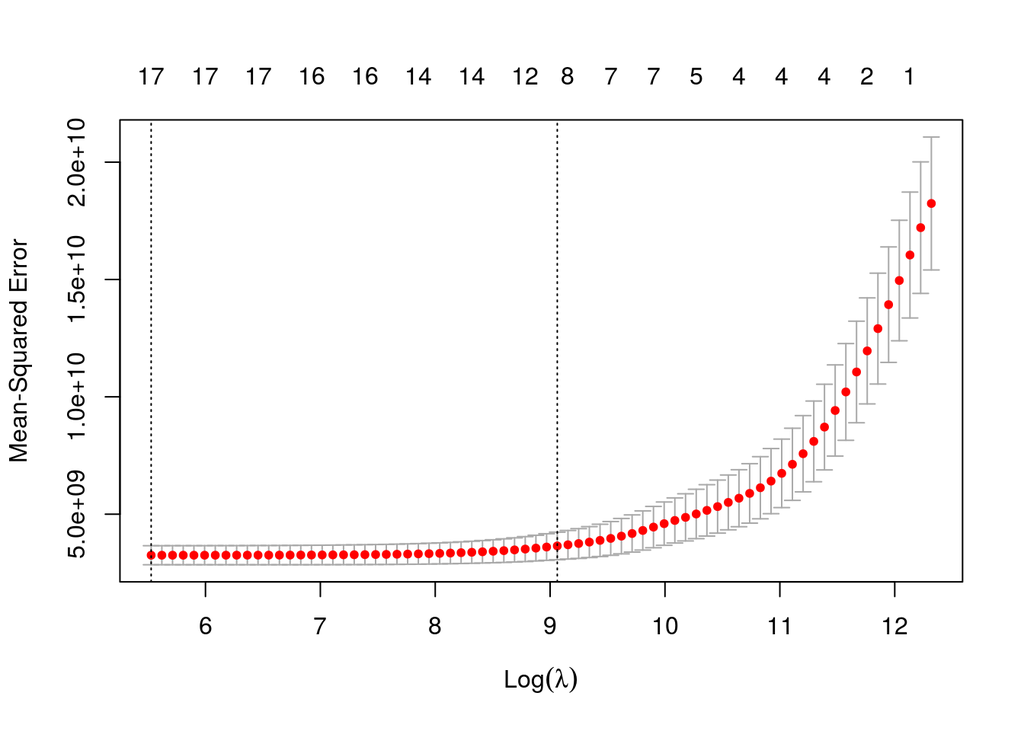

```r
# ElasticNet - mix of ridge and lasso

# define x and y matrix for glmnet
x <- model.matrix(Y~., data = dev2a) [,-c(1)] # drop last column
y <- dev2a$Y

cv_enet_mod <- cv.glmnet(x, y, alpha = 0.5, nlambda = 100, lambda.min.ratio = 0.0001)
plot(cv_enet_mod)
```

```r
best_lambda_enet <- cv_enet_mod$lambda.min
best_lambda_enet
```

```
## [1] 251.4473
```

```r
# get coefficients
coef(cv_enet_mod, s = 'lambda.min')
```

```
## 18 x 1 sparse Matrix of class "dgCMatrix"
##                         1
## (Intercept) -2.716519e+06
## X1           1.004771e+02
## X2          -4.354419e+03
## X3           4.959076e+03
## X4           6.700635e+03
## X5           1.479640e+04
## X6           1.557796e+04
## X7           1.434487e+03
## X10          1.007943e+00
## X11         -2.907529e+04
## X8_2        -1.186655e+05
## X8_3        -1.238218e+05
## X9_2        -2.012852e+04
## X9_3        -7.362522e+03
## X9_4         1.600763e+03
## X9_5        -2.428876e+04
## X9_6         4.479295e+03
## X9_7        -3.261622e+04
```

```r
# predict
pred_dev2a <- predict(cv_enet_mod, s = best_lambda_enet, type = 'link', newx = x)

# hold out set
# define x and y matrix for glmnet
x1 <- model.matrix(Y~., data = ho2a) [,-c(1)] # drop last column
y1 <- ho2a$Y
```

g-) Score all models on hold-out sample. Compare the SSEs, $R^2$ and select the best model. (10 points)

```r
# Measure performance with SSE
sse <- function(actual, predicted) {
  sum((actual - predicted)^2)
}

# MEasure performance with RSq
r2 <- function(actual, predicted) {
  1-sum((actual - predicted)^2)/((length(actual)-1)*var(actual))
}

predlm <- predict(lm2b_log, ho2a)
predlmbest <- predict(lmbest2c, ho2a)
predlmbest2cfinal <- predict(lm_best2c_final, ho2a)
predtree2d <- predict(tree2d, ho2a)
hoa2a_nn_pred <- compute(dev2a_nn, ho2a_norm)
pred_ho2a <- predict(cv_enet_mod, s = best_lambda_enet, type = 'link', newx = x1)
```

## Question 3

Use the “Final Exam Fall 2020 Question 2.csv” data set in Question 2. Create a binary response variable Y, called high quality, by letting Y=1 if quality variable equals to 1 otherwise 0. (20 points)

a-) Fit a model to predict Y, ensure that all variables are significant by using the backward elimination to build your model. Use $\alpha=0.05$ and ensure that all variables are significant.(10 points)

```r
p3 <- p2
colnames(p3)
```

```
##  [1] "Sales.price"          "Finished.square.feet" "Number.of.bedrooms"
##  [4] "Number.of.bathrooms"  "Air.conditioning"     "Garage.size"
##  [7] "Pool"                 "Year.built"           "Quality"
## [10] "Style"                "Lot.size"             "Adjacent.to.highway"
```

```r
str(p3)
```

```
## 'data.frame':    522 obs. of  12 variables:
##  $ Sales.price         : int  360000 340000 250000 205500 275500 248000 229900 150000 195000 160000 ...
##  $ Finished.square.feet: int  3032 2058 1780 1638 2196 1966 2216 1597 1622 1976 ...
##  $ Number.of.bedrooms  : int  4 4 4 4 4 4 3 2 3 3 ...
##  $ Number.of.bathrooms : int  4 2 3 2 3 3 2 1 2 3 ...
##  $ Air.conditioning    : int  1 1 1 1 1 1 1 1 1 0 ...
##  $ Garage.size         : int  2 2 2 2 2 5 2 1 2 1 ...
##  $ Pool                : int  0 0 0 0 0 1 0 0 0 0 ...
##  $ Year.built          : int  1972 1976 1980 1963 1968 1972 1972 1955 1975 1918 ...
##  $ Quality             : int  2 2 2 2 2 2 2 2 3 3 ...
##  $ Style               : int  1 1 1 1 7 1 7 1 1 1 ...
##  $ Lot.size            : int  22221 22912 21345 17342 21786 18902 18639 22112 14321 32358 ...
##  $ Adjacent.to.highway : int  0 0 0 0 0 0 0 0 0 0 ...
```

```r
summary(p3)
```

```
##   Sales.price     Finished.square.feet Number.of.bedrooms Number.of.bathrooms
##  Min.   : 84000   Min.   : 980         Min.   :0.000      Min.   :0.000
##  1st Qu.:180000   1st Qu.:1701         1st Qu.:3.000      1st Qu.:2.000
##  Median :229900   Median :2061         Median :3.000      Median :3.000
##  Mean   :277894   Mean   :2261         Mean   :3.471      Mean   :2.642
##  3rd Qu.:335000   3rd Qu.:2636         3rd Qu.:4.000      3rd Qu.:3.000
##  Max.   :920000   Max.   :5032         Max.   :7.000      Max.   :7.000
##  Air.conditioning  Garage.size       Pool           Year.built
##  Min.   :0.0000   Min.   :0.0   Min.   :0.00000   Min.   :1885
##  1st Qu.:1.0000   1st Qu.:2.0   1st Qu.:0.00000   1st Qu.:1956
##  Median :1.0000   Median :2.0   Median :0.00000   Median :1966
##  Mean   :0.8314   Mean   :2.1   Mean   :0.06897   Mean   :1967
##  3rd Qu.:1.0000   3rd Qu.:2.0   3rd Qu.:0.00000   3rd Qu.:1981
##  Max.   :1.0000   Max.   :7.0   Max.   :1.00000   Max.   :1998
##     Quality          Style          Lot.size     Adjacent.to.highway
##  Min.   :1.000   Min.   :1.000   Min.   : 4560   Min.   :0.00000
##  1st Qu.:2.000   1st Qu.:1.000   1st Qu.:17205   1st Qu.:0.00000
##  Median :2.000   Median :2.000   Median :22200   Median :0.00000
##  Mean   :2.184   Mean   :3.328   Mean   :24370   Mean   :0.02107
##  3rd Qu.:3.000   3rd Qu.:7.000   3rd Qu.:26787   3rd Qu.:0.00000
##  Max.   :3.000   Max.   :7.000   Max.   :86830   Max.   :1.00000
```

```r
tail(p3)
```

|  | Sales.price | Finished.square.feet | Number.of.bedrooms | Number.of.bathrooms | Air.conditioning | Garage.size | Pool | Year.built | Quality | Style | Lot.size | Adjacent.to.highway |
| --- | --- | --- | --- | --- | --- | --- | --- | --- | --- | --- | --- | --- |
| 517 | 136900 | 1409 | 2 | 1 | 0 | 1 | 0 | 1951 | 3 | 1 | 28421 | 0 |
| 518 | 137000 | 1655 | 2 | 1 | 0 | 1 | 0 | 1935 | 3 | 1 | 54651 | 0 |
| 519 | 185000 | 1944 | 3 | 2 | 1 | 2 | 0 | 1939 | 3 | 6 | 17999 | 0 |
| 520 | 133500 | 1922 | 3 | 1 | 0 | 2 | 0 | 1950 | 3 | 1 | 14805 | 0 |
| 521 | 124000 | 1480 | 3 | 2 | 1 | 2 | 0 | 1953 | 3 | 1 | 28351 | 0 |
| 522 | 95500 | 1184 | 2 | 1 | 0 | 1 | 0 | 1951 | 3 | 1 | 14786 | 0 |

```r
# rename columns
p3a <- p3
colnames(p3a) <- c('X0', 'X1', 'X2', 'X3', 'X4', 'X5', 'X6', 'X7', 'X8', 'X9', 'X10', 'X11')
str(p3a)
```

```
## 'data.frame':    522 obs. of  12 variables:
##  $ X0 : int  360000 340000 250000 205500 275500 248000 229900 150000 195000 160000 ...
##  $ X1 : int  3032 2058 1780 1638 2196 1966 2216 1597 1622 1976 ...
##  $ X2 : int  4 4 4 4 4 4 3 2 3 3 ...
##  $ X3 : int  4 2 3 2 3 3 2 1 2 3 ...
##  $ X4 : int  1 1 1 1 1 1 1 1 1 0 ...
##  $ X5 : int  2 2 2 2 2 5 2 1 2 1 ...
##  $ X6 : int  0 0 0 0 0 1 0 0 0 0 ...
##  $ X7 : int  1972 1976 1980 1963 1968 1972 1972 1955 1975 1918 ...
##  $ X8 : int  2 2 2 2 2 2 2 2 3 3 ...
##  $ X9 : int  1 1 1 1 7 1 7 1 1 1 ...
##  $ X10: int  22221 22912 21345 17342 21786 18902 18639 22112 14321 32358 ...
##  $ X11: int  0 0 0 0 0 0 0 0 0 0 ...
```

```r
table(p3a$X4) # 0,1 no dummy needed - AC Yes No
```

```
##
##   0   1
##  88 434
```

```r
table(p3a$X6) # 0,1 no dummy needed - Pool yes no
```

```
##
##   0   1
## 486  36
```

```r
table(p3a$X9) # 1-7 - dummy needed - 7 different style types
```

```
##
##   1   2   3   4   5   6   7
## 214  58  64  11  18  18 139
```

```r
table(p3a$X11) # # 0,1 - no dummy needed
```

```
##
##   0   1
## 511  11
```

```r
# create dummy variables for x9
p3a <- dummy_cols(p3a, select_columns = 'X9')
p3a <- dummy_cols(p3a, select_columns = 'X8')

#check
str(p3a)
```

```
## 'data.frame':    522 obs. of  22 variables:
##  $ X0  : int  360000 340000 250000 205500 275500 248000 229900 150000 195000 160000 ...
##  $ X1  : int  3032 2058 1780 1638 2196 1966 2216 1597 1622 1976 ...
##  $ X2  : int  4 4 4 4 4 4 3 2 3 3 ...
##  $ X3  : int  4 2 3 2 3 3 2 1 2 3 ...
##  $ X4  : int  1 1 1 1 1 1 1 1 1 0 ...
##  $ X5  : int  2 2 2 2 2 5 2 1 2 1 ...
##  $ X6  : int  0 0 0 0 0 1 0 0 0 0 ...
##  $ X7  : int  1972 1976 1980 1963 1968 1972 1972 1955 1975 1918 ...
##  $ X8  : int  2 2 2 2 2 2 2 2 3 3 ...
##  $ X9  : int  1 1 1 1 7 1 7 1 1 1 ...
##  $ X10 : int  22221 22912 21345 17342 21786 18902 18639 22112 14321 32358 ...
##  $ X11 : int  0 0 0 0 0 0 0 0 0 0 ...
##  $ X9_1: int  1 1 1 1 0 1 0 1 1 1 ...
##  $ X9_2: int  0 0 0 0 0 0 0 0 0 0 ...
##  $ X9_3: int  0 0 0 0 0 0 0 0 0 0 ...
##  $ X9_4: int  0 0 0 0 0 0 0 0 0 0 ...
##  $ X9_5: int  0 0 0 0 0 0 0 0 0 0 ...
##  $ X9_6: int  0 0 0 0 0 0 0 0 0 0 ...
##  $ X9_7: int  0 0 0 0 1 0 1 0 0 0 ...
##  $ X8_1: int  0 0 0 0 0 0 0 0 0 0 ...
##  $ X8_2: int  1 1 1 1 1 1 1 1 0 0 ...
##  $ X8_3: int  0 0 0 0 0 0 0 0 1 1 ...
```

```r
# drop redundant columns and check
colnames(p3a)
```

```
##  [1] "X0"   "X1"   "X2"   "X3"   "X4"   "X5"   "X6"   "X7"   "X8"   "X9"
## [11] "X10"  "X11"  "X9_1" "X9_2" "X9_3" "X9_4" "X9_5" "X9_6" "X9_7" "X8_1"
## [21] "X8_2" "X8_3"
```

```r
p3dummy <- p3a[,-c(9, 10, 13,21,22)]; colnames(p3dummy)
```

```
##  [1] "X0"   "X1"   "X2"   "X3"   "X4"   "X5"   "X6"   "X7"   "X10"  "X11"
## [11] "X9_2" "X9_3" "X9_4" "X9_5" "X9_6" "X9_7" "X8_1"
```

```r
ff<-lm(X8_1~.,data=p3dummy)
ff$coefficients
```

```
##   (Intercept)            X0            X1            X2            X3
## -6.523588e-01  1.858207e-06  5.369801e-05 -2.757482e-02 -2.058345e-02
##            X4            X5            X6            X7           X10
## -4.574611e-02  3.271961e-02 -1.066702e-02  1.942285e-04 -3.115059e-06
##           X11          X9_2          X9_3          X9_4          X9_5
##  3.493033e-02 -2.919030e-02 -8.216569e-02 -5.924888e-02 -7.606585e-03
##          X9_6          X9_7
## -1.641641e-01 -8.015734e-02
```

b-) Conduct the Hosmer-Lemeshow goodness of fit test for the appropriateness of the logistic regression function by forming five groups. State the alternatives, decision rule, and conclusion. (5points)

```r
#hoslem.test(ff$y,fitted(ff),g=5)
```

c-) What is the estimated probability of each house from the data given below having good quality? (Output should have 3 probabilities). Copy and paste the code below on r (5points)

test.dat<-data.frame(matrix(c(559000,2791,3,4,1,3,0,1992,1,30595,0,535000,3381,5,4,1,3,0,1988,7,23172, 0,525000,3459,5,4,1,2,0,1978,5,35351,0),byrow=T,nrow=3,ncol=11))

dimnames(test.dat)[[2]]<-c(“Sales.price”,“Finished.square.feet”,“Number.of.bedrooms”,“Number.of.bathroom”, “Air.conditioning”,“Garage.size”,“Pool”,“Year.built”,“Style”,“Lot.size”,“Adjacent.to.highway”)

## Question 4

Use ships data sets in the MASS package. Copy and paste and following code “library(MASS);data(ships,package =”MASS“)”. (10 points, 5 points each)

Data contains the number of wave damage incidents and aggregate months of service for different types of ships broken down by year of construction and period of operation.

a-) Fit linear models with the number of damage incidents as the response and all other variables are predictors. Is the model significant?

```r
data(ships,package = "MASS")
str(ships)
```

```
## 'data.frame':    40 obs. of  5 variables:
##  $ type     : Factor w/ 5 levels "A","B","C","D",..: 1 1 1 1 1 1 1 1 2 2 ...
##  $ year     : int  60 60 65 65 70 70 75 75 60 60 ...
##  $ period   : int  60 75 60 75 60 75 60 75 60 75 ...
##  $ service  : int  127 63 1095 1095 1512 3353 0 2244 44882 17176 ...
##  $ incidents: int  0 0 3 4 6 18 0 11 39 29 ...
```

```r
# linear model
lm4a <- lm(incidents~., data = ships)
summary(lm4a)
```

```
##
## Call:
## lm(formula = incidents ~ ., data = ships)
##
## Residuals:
##      Min       1Q   Median       3Q      Max
## -19.5549  -3.4577  -0.0849   2.3616  16.6209
##
## Coefficients:
##               Estimate Std. Error t value Pr(>|t|)
## (Intercept) -2.746e+01  1.856e+01  -1.479   0.1489
## typeB        8.622e+00  4.926e+00   1.750   0.0897 .
## typeC       -3.296e+00  3.662e+00  -0.900   0.3748
## typeD       -2.430e+00  3.663e+00  -0.663   0.5119
## typeE       -6.495e-01  3.663e+00  -0.177   0.8604
## year         1.528e-01  2.196e-01   0.696   0.4915
## period       3.124e-01  1.547e-01   2.020   0.0519 .
## service      1.102e-03  2.047e-04   5.385 6.47e-06 ***
## ---
## Signif. codes:  0 '***' 0.001 '**' 0.01 '*' 0.05 '.' 0.1 ' ' 1
##
## Residual standard error: 7.322 on 32 degrees of freedom
## Multiple R-squared:  0.8035, Adjusted R-squared:  0.7605
## F-statistic: 18.69 on 7 and 32 DF,  p-value: 1.182e-09
```

```r
# linear model will not work since this is count - fit poisson
modp <- glm(incidents ~ ., family = poisson, data = ships)
summary(modp)
```

```
##
## Call:
## glm(formula = incidents ~ ., family = poisson, data = ships)
##
## Deviance Residuals:
##     Min       1Q   Median       3Q      Max
## -4.1013  -1.9648  -0.5380   0.9899   4.6212
##
## Coefficients:
##               Estimate Std. Error z value Pr(>|z|)
## (Intercept) -5.706e+00  1.221e+00  -4.673 2.96e-06 ***
## typeB        8.135e-01  2.023e-01   4.021 5.79e-05 ***
## typeC       -1.205e+00  3.275e-01  -3.679 0.000234 ***
## typeD       -8.595e-01  2.875e-01  -2.989 0.002795 **
## typeE       -2.226e-01  2.348e-01  -0.948 0.343173
## year         4.519e-02  1.341e-02   3.370 0.000752 ***
## period       6.055e-02  8.945e-03   6.768 1.30e-11 ***
## service      5.970e-05  7.016e-06   8.509  < 2e-16 ***
## ---
## Signif. codes:  0 '***' 0.001 '**' 0.01 '*' 0.05 '.' 0.1 ' ' 1
##
## (Dispersion parameter for poisson family taken to be 1)
##
##     Null deviance: 730.25  on 39  degrees of freedom
## Residual deviance: 174.00  on 32  degrees of freedom
## AIC: 287.86
##
## Number of Fisher Scoring iterations: 6
```

b-) Predict the number of incidents for the following data point. ("copy and paste onto R)

test.data<-data.frame(type=“B”,year=60,period=60,service=44882)

```r
test.data<-data.frame(type="B",year=60,period=60,service=44882)
test.data
```

| type | year | period | service |
| --- | --- | --- | --- |
| B | 60 | 60 | 44882 |

```r
drop1(modp, test = 'Chi')
```

|  | Df | Deviance | AIC | LRT | Pr(>Chi) |
| --- | --- | --- | --- | --- | --- |
|  | NA | 173.9961 | 287.8626 | NA | NA |
| type | 4 | 250.2443 | 356.1108 | 76.24818 | 1.084833e-15 |
| year | 1 | 185.7515 | 297.6180 | 11.75540 | 6.066696e-04 |
| period | 1 | 225.8499 | 337.7163 | 51.85372 | 5.979338e-13 |
| service | 1 | 250.3101 | 362.1766 | 76.31396 | 2.419677e-18 |

```r
pred2 <- predict(modp, test.data, type = 'link', se.fit = TRUE);

exp(pred2$fit)
```

```
##        1
## 62.24901
```

## Question 5

Refer to question 2-C and your final model . There could be potential outliers in the model. Build a robust regression model (use the same variables) and compare your regression model and outputs with the model you built in question 2-C. (10 Points)

```r
# model in 2c summarized again
summary(lmbest2c)
```

```
##
## Call:
## lm(formula = Y ~ ., data = best2c_df)
##
## Residuals:
##     Min      1Q  Median      3Q     Max
## -172551  -27786   -3821   22386  206320
##
## Coefficients:
##               Estimate Std. Error t value Pr(>|t|)
## (Intercept) -2.562e+06  4.387e+05  -5.841 1.17e-08 ***
## X1           9.861e+01  7.782e+00  12.672  < 2e-16 ***
## X7           1.351e+03  2.223e+02   6.076 3.17e-09 ***
## X5           1.582e+04  5.572e+03   2.839 0.004779 **
## X10          9.619e-01  2.668e-01   3.605 0.000356 ***
## X9_7        -2.597e+04  8.456e+03  -3.072 0.002293 **
## X3           3.737e+03  4.708e+03   0.794 0.427789
## X4           8.169e+03  9.139e+03   0.894 0.372011
## X8_2        -1.238e+05  1.129e+04 -10.960  < 2e-16 ***
## X8_3        -1.270e+05  1.554e+04  -8.177 5.23e-15 ***
## ---
## Signif. codes:  0 '***' 0.001 '**' 0.01 '*' 0.05 '.' 0.1 ' ' 1
##
## Residual standard error: 54860 on 355 degrees of freedom
## Multiple R-squared:  0.8385, Adjusted R-squared:  0.8344
## F-statistic: 204.7 on 9 and 355 DF,  p-value: < 2.2e-16
```

```r
# using huber weights
rr_huber <- rlm(Y~., data = best2c_df)
summary(rr_huber)
```

```
##
## Call: rlm(formula = Y ~ ., data = best2c_df)
## Residuals:
##     Min      1Q  Median      3Q     Max
## -173042  -24324   -1704   24701  218330
##
## Coefficients:
##             Value         Std. Error    t value
## (Intercept) -2070314.5140   369697.8880       -5.6000
## X1                93.6317        6.5579       14.2778
## X7              1098.8564      187.2993        5.8668
## X5             13163.2986     4695.6924        2.8033
## X10                0.9412        0.2248        4.1859
## X9_7          -26367.3598     7125.7128       -3.7003
## X3             11002.9023     3967.1356        2.7735
## X4              7321.6005     7701.8498        0.9506
## X8_2         -125475.2190     9517.2431      -13.1840
## X8_3         -125604.3826    13093.0671       -9.5932
##
## Residual standard error: 36620 on 355 degrees of freedom
```

The robust regression model has a lower residual standard error as seen above